# 4. Case Study

3 gennaio 2023

#### Package

MMRFVariant 2.0.0

# 1 Preliminary steps (Downloading and Importing datasets)

**Preliminary steps**

Downloading and importing MMRF-RG datasets:

```r
patient<-MMRF_CoMMpass_IA15_PER_PATIENT

trt<-MMRF_CoMMpass_IA15_STAND_ALONE_TRTRESP

variant.ann<-MMRF_CoMMpass_IA15a_All_Canonical_Variants
```

# 2 Analyze the topN recurrent variants in the complete samples cohort

## 2.1 Heatmap of the N# of variants occurrence in the complete samples cohort

**MMRFVariant_PlotVariantsbyGene**

[figure not shown]

Figure 1: Heatmap of the N# of variants occurrence in the complete cohort

```r
variants.plot.all<-MMRFVariant_PlotVariantsbyGene(variant.ann,height=10, width=20,topN=10,

                                                  filenm="PlotVariantsbyGene_heatmapAll")
```

## 2.2 Get the list of variants found in the in the complete samples cohort ranked by the occurrence number

**MMRFVariant_GetVariantsbyGene**

```r
ListSNPs.all<-MMRFVariant_GetVariantsbyGene(variant.ann)


ListSNPs.all<-ListSNPs.all[order(ListSNPs.all$count, decreasing = TRUE),]

ListSNPs.all.10<-head(unique(ListSNPs.all),10)
```

```r
datatable(as.data.frame(ListSNPs.all.10),
              options = list(scrollX = TRUE, keys = TRUE, pageLength = 5),
              rownames = FALSE)
```

| Gene | dbSNP | count |
| --- | --- | --- |
| IGLV3-1 | rs61731685 | 210 |
| IGHV2-70 | rs2157615 | 199 |
| IGHV3-71 | rs2157615 | 199 |
| IGHV2-70 | rs367953381 | 108 |
| IGHV3-71 | rs367953381 | 106 |
| IGHV2-70 | rs370560636 | 102 |
| IGHV3-71 | rs370560636 | 102 |
| IGLV3-1 | rs73880715 | 102 |
| AL122127.1 | rs116293337 | 91 |
| AL122127.3 | rs116293337 | 91 |

## 2.3 Perform the impact table (ordered by ascending SIFT and descending Poliphen-2)

**MMRFVariant_GetImpact**

For semplification purposes, we visualize a subset of columns and rows.

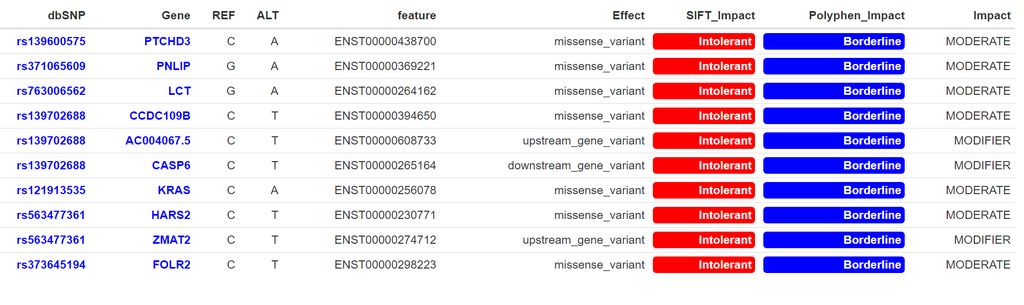

```r
impact.table.all<-MMRFVariant_GetImpact(variant.ann,ListSNPs.all$dbSNP)

impact.table.all.sub<-dplyr::select(impact.table.all,dbSNP,Gene,REF,ALT,feature,Effect,
                                SIFT_Impact,Polyphen_Impact,Impact)

head(unique(impact.table.all.sub),10)
```

## 2.4 Perform the Impact-Effect plot

**MMRFVariant_PlotbyEffectImpact**

[figure not shown]

```r
ListSNPs.all.100<-head(ListSNPs.bycount.all$dbSNP,100)

plot.impact.effect.all<-MMRFVariant_PlotbyEffectImpact(variant.ann,ListSNPs.all.100,topN=3,height=20,
                                                   width=30, filenm="PlotbyEffectImpactAll")
```

# 3 Prioritizing variants in a known Multiple Myeloma (MM) disease-causing gene set

The six gene-signature including the genes KRAS, NRAS, TP53, FAM46C, DIS3, BRAF have a high recurrence rate and may play important roles in the pathogenesis, progression and prognosis of MM. This case study shows how MMRFVariant performs the integrative analysis of variants in that six gene-signature to prioritize pathogenic variants involved in the MM.

The Figure below shows the workflow that describes graphically step by step the procedure carried out to perform this case of study.

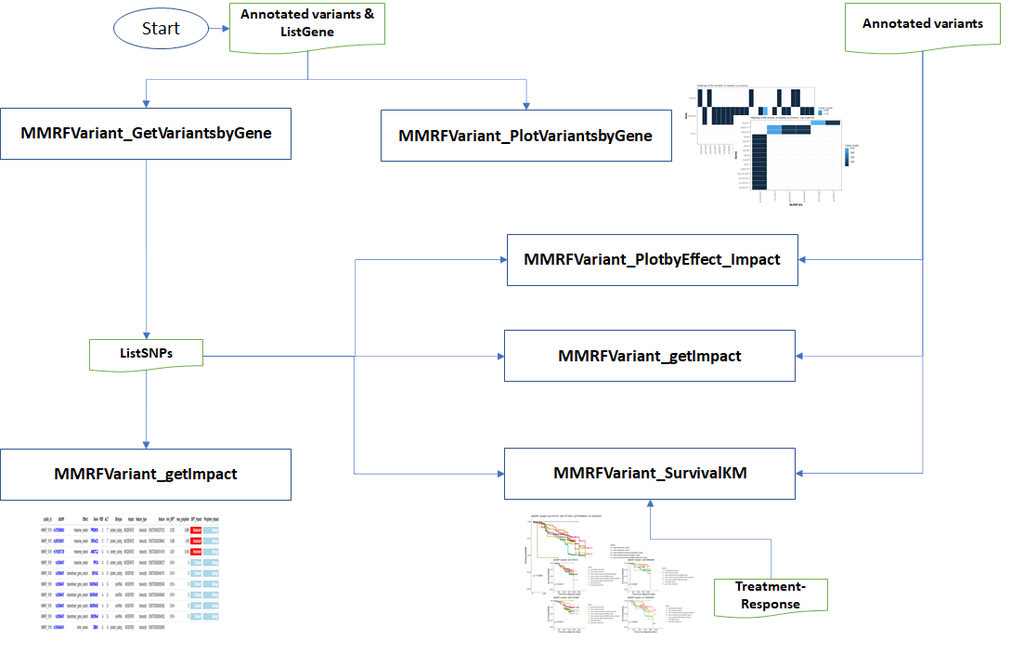

Figure 4: The workflow describes graphically step by step the procedure carried out to perform this case of study

## 3.1 Set the list of gene “ListGene” to explore

```r
ListGene<-c("KRAS", "NRAS","TP53","FAM46C","DIS3","BRAF")
```

## 3.2 Draw the Heatmap of the N# of variants occurring in “ListGene”

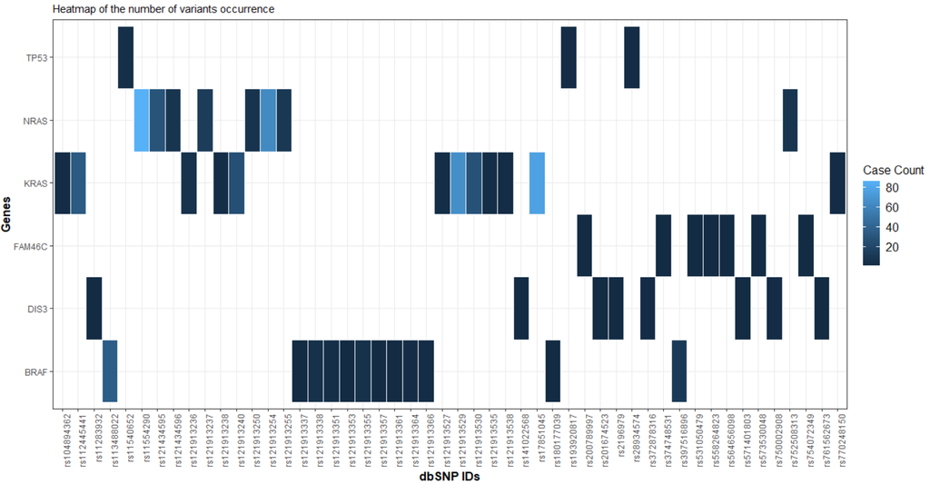

```r
variants.plot<-MMRFVariant_PlotVariantsbyGene(variant.ann,ListGene,height=15,
                                              width=20,topN=50,
                                              filenm="PlotVariantsbyGene_heatmap")
```

## 3.3 Get the list of Variants found in the gene set

```r
ListSNPs<-MMRFVariant_GetVariantsbyGene(variant.ann, ListGene)

head(ListSNPs,20)
```

```r
datatable(as.data.frame(ListSNPs),
              options = list(scrollX = TRUE, keys = TRUE, pageLength = 5),
              rownames = FALSE)
```

| Gene | dbSNP | count |
| --- | --- | --- |
| NRAS | rs11554290 | 86 |
| KRAS | rs17851045 | 77 |
| KRAS | rs121913529 | 66 |
| NRAS | rs121913254 | 63 |
| BRAF | rs113488022 | 35 |
| KRAS | rs112445441 | 33 |
| NRAS | rs121434595 | 29 |
| KRAS | rs121913530 | 28 |
| KRAS | rs121913240 | 26 |
| NRAS | rs121913237 | 13 |

[output cut: 78 more lines]

## 3.4 Plot the Impact-Effect of Variants

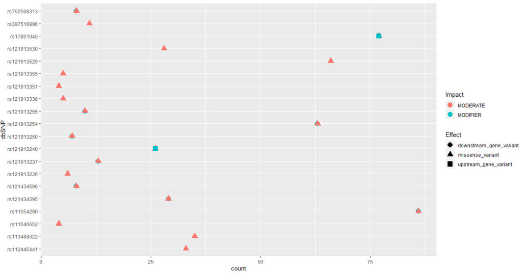

Figure 6: MMRFVariant_PlotbyEffectImpact plot

```r
plot.impact.effect<-MMRFVariant_PlotbyEffectImpact(variant.ann,ListSNPs,topN=50,height=30,
                                                   width=15, filenm="PlotbyEffectImpact")
```

## 3.5 Perform the impact table (ordered by ascending SIFT and descending Poliphen-2)

```r
impact.table<-MMRFVariant_GetImpact(variant.ann,ListSNPs)
```

For semplification purposes, we visualize a subset of columns and rows

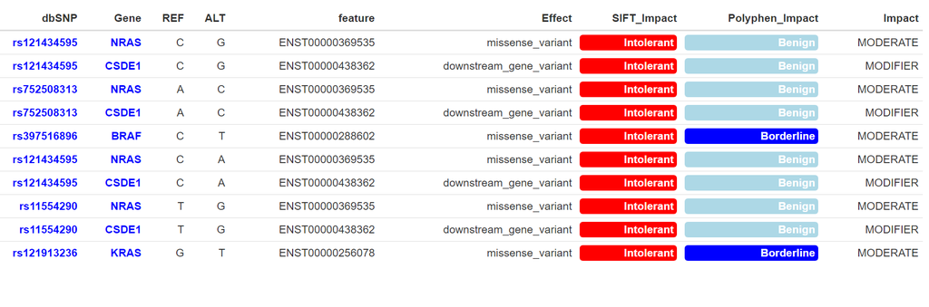

Figure 7: Impact table of each SNP in ListGene

```r
impact.table.sub<-dplyr::select(impact.table,dbSNP,Gene,REF,ALT,feature,Effect,
                                SIFT_Impact,Polyphen_Impact,Impact)

head(unique(impact.table.sub),10)
```

## 3.6 Focusing on NRAS gene

```r
ListSNPs_NRAS<-MMRFVariant_GetVariantsbyGene(variant.ann,"NRAS")
```

```r
datatable(as.data.frame(ListSNPs_NRAS),
              options = list(scrollX = TRUE, keys = TRUE, pageLength = 5),
              rownames = FALSE)
```

| Gene | dbSNP | count |
| --- | --- | --- |
| NRAS | rs11554290 | 86 |
| NRAS | rs121913254 | 63 |
| NRAS | rs121434595 | 29 |
| NRAS | rs121913237 | 13 |
| NRAS | rs121913255 | 10 |
| NRAS | rs121434596 | 8 |
| NRAS | rs752508313 | 8 |
| NRAS | rs121913250 | 7 |
| NRAS | rs753210209 | 1 |

```r
impact.table_NRAS<-MMRFVariant_GetImpact(variant.ann,ListSNPs_NRAS$dbSNP)
```

For semplification purposes, we visualize a subset of columns and rows

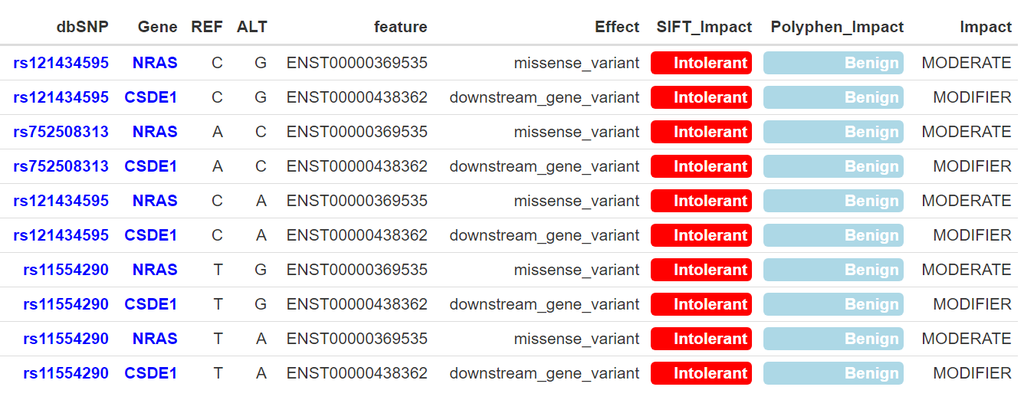

Figure 8: Impact table of each SNP in NRAS

```r
impact.table_NRAS<-dplyr::select(impact.table_NRAS,dbSNP,Gene,REF,ALT,
                                feature,Effect,SIFT_Impact,Polyphen_Impact,Impact)

head(unique(impact.table_NRAS),10)
```

## 3.7 Plot the Impact-Effect of SNPs in NRAS gene

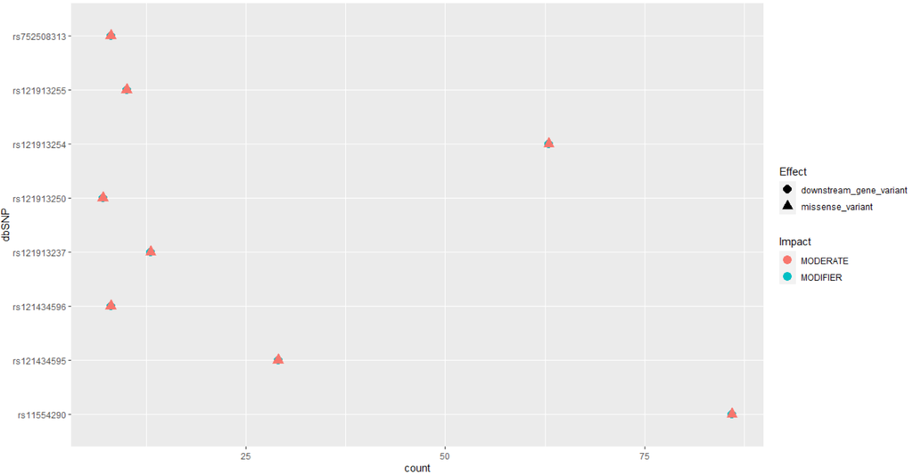

```r
plot.impact.effect_NRAS<-MMRFVariant_PlotbyEffectImpact(variant.ann,ListSNPs_NRAS,topN=50,height=30,
                                                         width=15, filenm="PlotbyEffectImpact_NRAS")
```